# ENSANUT 2018: Indice de Masa Corporal

Analizaremos los datos de Antropometría de la [Encuesta Nacional de Salud y Nutrición, ENSANUT 2018](https://ensanut.insp.mx/encuestas/ensanut2018/descargas.php).

## Importar y curar los datos

Primero leemos los datos que están en formato CSV. Para ello usaremos la función read_csv de tidyverse.

Esta base de datos tiene 33,818 obervaciones y 57 variables. Nos quedaremos por ahora con unas cuantas.

Primero generamos la variable PesoPromedio. Porque cada participante fue pesado 2 veces, y se usaron dos variables para los menores de 60 años de edad (PESO1_1 y PESO1_2) y dos para los mayores de 60 años de edad (PESO12_1 y PESO12_2).

```r
# Creamos la variable PesoPromedio
en_antropometria <- mutate(en_antropometria, PesoPromedio = rowMeans(sapply(select(en_antropometria,starts_with("PESO")),as.numeric),na.rm = TRUE))
```

Similarmente, generamos TallaPromedio. Porque cada participante fue medido en centímetros 2 veces, y se usaron dos variables para los menores de 60 años de edad (TALLA4_1 y TALLA4_2) y dos para los mayores de 60 años de edad (TALLA15_1 y TALLA15_2).

```r
# Creamos la variable TallaPromedio (cuidado: existe una variable TALLAPIE17*)
en_antropometria <- mutate(en_antropometria, TallaPromedio = rowMeans(sapply(select(en_antropometria,starts_with("TALLA4") | starts_with("TALLA15")),as.numeric),na.rm = TRUE))
```

```r
# IMC (escalamos porque la talla está en cm)
en_antropometria <- mutate(en_antropometria, IMC = 10000*PesoPromedio/(TallaPromedio*TallaPromedio))
```

Nos quedaremos con las variables IMC, TallaPromedio, PesoPromedio, Edad, EntidadFederativa, Sexo, EstratoSociodemografico Filtremos los casos de mujeres embarazadas, sujetos amputados y sujetos no pesados o no medidos.

```r
# Seleccionar algunas variables y filtrar mujeres embarazadas, amputados y no medidos
en_AntrpMini <-
  filter(en_antropometria, is.na(P11) | as.numeric(P11) == 4 ) %>%  # menores de 60 (NA) o no-amputados
  filter( TallaPromedio < 222  & PesoPromedio < 222 & IMC < 200) %>%  # Quitar los no medidos = 222.2
  filter( is.na(P6) | as.numeric(P6) == 2 | as.numeric(P6) == 4 ) %>% # Quedarse con mujeres no embarazadas o que no se les pregunta.
  select(IMC, TallaPromedio, PesoPromedio, EDAD, ENT, SEXO, ESTRATO, GPO_INSP, DOMINIO)
```

# IMC estratificado

Probemos ver el IMC en función de: SEXO, ESTRATO, EDAD y ENTIDAD

### SEXO (1: hombre, 2: mujer )

```r
group_by(en_AntrpMini, SEXO) %>%
  summarise(IMC_Promedio = mean(IMC), IMC_DesvEst = sd(IMC))
```

| SEXO | IMC_Promedio | IMC_DesvEst |
| --- | --- | --- |
| 1 | 23.49807 | 6.615235 |
| 2 | 24.94503 | 7.438500 |

Es más interesante graficar las distribuciones

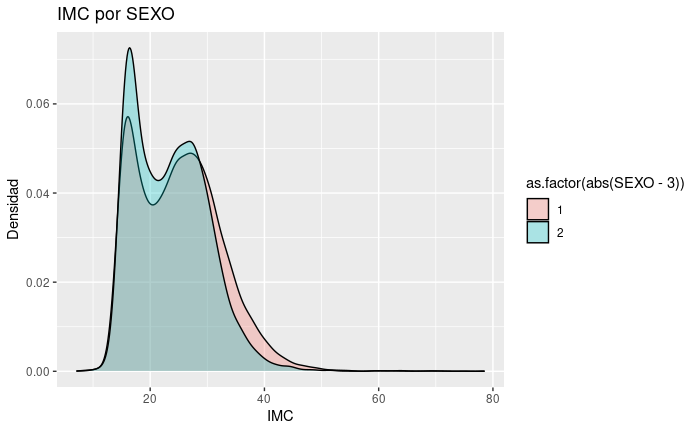

```r
ggplot(en_AntrpMini, aes(x=IMC, fill=as.factor(abs(SEXO-3)))) +
         geom_density(alpha=.3) +
  labs(title = "IMC por SEXO", y="Densidad")
```

#### Adolescentes por SEXO

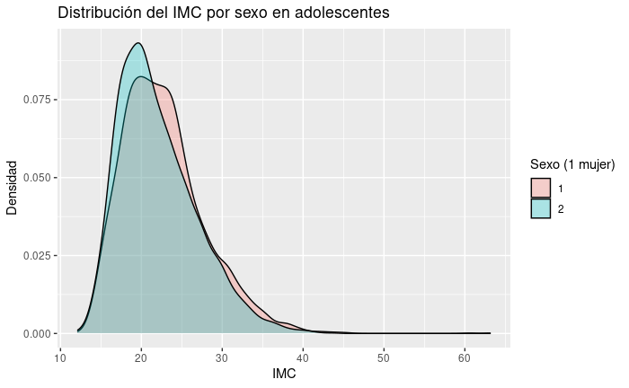

```r
ggplot(en_AntrpMini[as.numeric(en_AntrpMini$EDAD) > 9 & as.numeric(en_AntrpMini$EDAD) < 20,], aes(x=IMC, fill=as.factor(abs(SEXO-3)))) +
         geom_density(alpha=.3) +
  labs(fill="Sexo (1 mujer)", title="Distribución del IMC por sexo en adolescentes", y="Densidad")
```

### Grupo de edad (1: Preescolar, 2: Escolar, 3: Adolescentes, 4: Adultos)

Summary

```r
group_by(en_AntrpMini[en_AntrpMini$GPO_INSP > 0,], GPO_INSP) %>%
  summarise(IMC_Promedio = mean(IMC), IMC_DesvEst = sd(IMC))
```

| GPO_INSP | IMC_Promedio | IMC_DesvEst |
| --- | --- | --- |
| 1 | 16.51502 | 1.735395 |
| 2 | 17.83948 | 3.488979 |
| 3 | 23.04479 | 4.868397 |
| 4 | 28.88817 | 5.754132 |

Plot

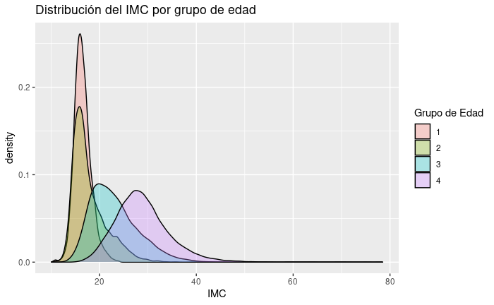

```r
ggplot(en_AntrpMini[en_AntrpMini$GPO_INSP > 0,], aes(x=IMC, fill=as.factor(GPO_INSP))) +
         geom_density(alpha=.3)+
  labs(fill="Grupo de Edad", title="Distribución del IMC por grupo de edad")
```

Boxplot

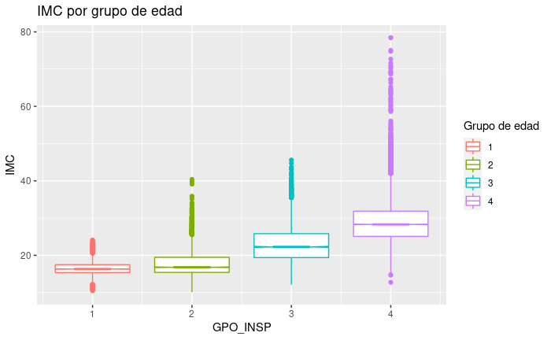

```r
ggplot(en_AntrpMini[en_AntrpMini$GPO_INSP>0,], aes(x=GPO_INSP, y=IMC, color=as.factor(GPO_INSP)))+
  geom_boxplot(notch = TRUE) +
  labs(color="Grupo de edad", title="IMC por grupo de edad")
```

### Estrato Sociodemográfico (1-4)

```r
group_by(en_AntrpMini, ESTRATO) %>%
  summarise(IMC_Promedio = mean(IMC), IMC_DesvEst = sd(IMC))
```

| ESTRATO | IMC_Promedio | IMC_DesvEst |
| --- | --- | --- |
| 1 | 23.20871 | 6.748599 |
| 2 | 24.54012 | 7.249986 |
| 3 | 25.01847 | 6.987703 |
| 4 | 24.88139 | 7.000331 |

Plot

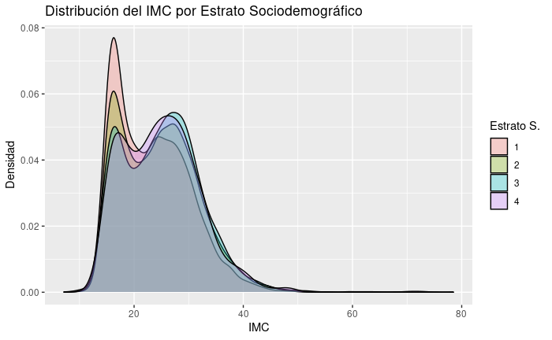

```r
ggplot(en_AntrpMini, aes(x=IMC, fill=as.factor(ESTRATO))) +
         geom_density(alpha=.3) +
  labs(title="Distribución del IMC por Estrato Sociodemográfico", fill="Estrato S.", y="Densidad")
```

No estoy seguro qué significa Estrato Sociodemográfico, pero exploraré si tiene que ver algo con el DOMINIO (rural y urbano)

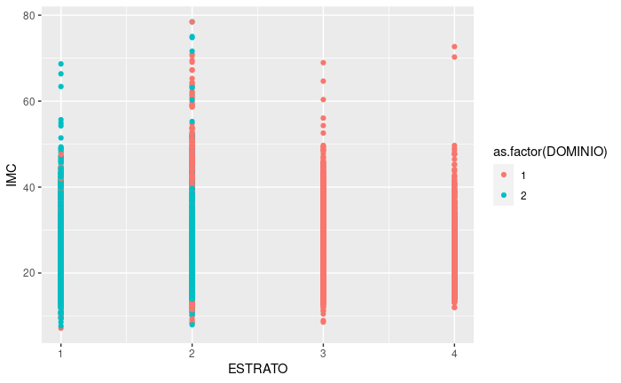

```r
ggplot(en_AntrpMini, aes(x=ESTRATO, y=IMC,color=as.factor(DOMINIO))) +
         geom_point()
```

### Dominio

Urbano=1, Rural=2

```r
group_by(en_AntrpMini, as.factor(DOMINIO)) %>%
  summarise(IMC_Promedio = mean(IMC), IMC_DesvEst = sd(IMC))
```

| as.factor(DOMINIO) | IMC_Promedio | IMC_DesvEst |
| --- | --- | --- |
| 1 | 24.59900 | 7.159567 |
| 2 | 23.64805 | 6.946964 |

Plot

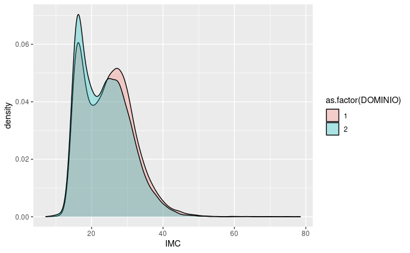

```r
ggplot(en_AntrpMini, aes(x=IMC, fill=as.factor(DOMINIO))) +
         geom_density(alpha=.3)
```

Solo adultos

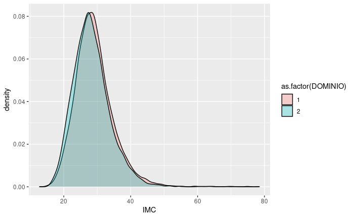

```r
ggplot(en_AntrpMini[as.numeric(en_AntrpMini$EDAD)>19,], aes(x=IMC, fill=as.factor(DOMINIO))) +
         geom_density(alpha=.3)
```

### Entidad

```r
group_by(en_AntrpMini, as.factor(ENT)) %>%
  summarise(IMC_Promedio = mean(IMC), IMC_DesvEst = sd(IMC))
```

| as.factor(ENT) | IMC_Promedio | IMC_DesvEst |
| --- | --- | --- |
| 01 | 23.77707 | 6.964716 |
| 02 | 25.71664 | 8.070968 |
| 03 | 24.82858 | 7.627894 |
| 04 | 25.19312 | 7.780866 |
| 05 | 24.09957 | 7.024316 |
| 06 | 24.82205 | 7.110983 |
| 07 | 23.30723 | 6.659230 |
| 08 | 24.54025 | 7.027615 |
| 09 | 25.69894 | 7.088851 |
| 10 | 24.19971 | 7.100133 |

[output cut: 22 more lines]

### Edad

Boxplot

[figure not shown]

```r
ggplot(en_AntrpMini, aes(x=EDAD, y=IMC, color=as.factor(GPO_INSP)))+
  geom_boxplot() +
  labs(color="ESTRATO", title="IMC por grupo de edad") +
  geom_smooth(method="gam")
```

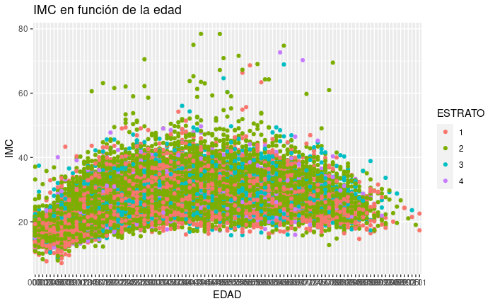

```r
ggplot(en_AntrpMini, aes(x=EDAD, y=IMC, color=as.factor(ESTRATO)))+
  geom_point() +
  labs(color="ESTRATO", title="IMC en función de la edad")
```

### Por Hacer…

1. Analisis cuantitativos.
2. Regresión logística para identificar los principales factores asociados a la obesidad (considerar más variables).
3. Shiny para ver la distribución geográfica del IMC y otras variables antropométricas.